# A Brief data transformation and visualization

Kawin Chinpong

2023-05-21

This is a R markdown which were demonstrated some (maybe) useful information on how tabular transformation and basic visualization is.

# Outline on this markdown

Information on this markdown is consisted of the following sections

- Library Loading
- (incidence table) Data Loading
- Data conversion from wide-format into long-format
- Basic visualization

# Library Loading

In this chapter, `tidyverse` which also included `readr` for data preprocessing and `ggplot2` for visualization, and `rgdal` will be loaded for main data performing while `sf` is for map transformation. Library `DT` were only used for tabular visualization in R-markdown only, not necessary.

```r
library(tidyverse)
library(rgdal)
library(sf)
library(DT)
```

# (incidence table) Data Loading

Suppose we quarterly collected incidence count of a disease for 2 consecutive years. Original result data maybe gathered like the following table, read it using `read_csv` which were loaded from `readr`.

```r
df_wide<-read_csv("input/incidence_table_wide.csv")
datatable(df_wide,caption="Quarter Incidence Table in Wide-format",options=list(pageLength=5,scrollX=TRUE))
```

|  | area | year | q1 | q2 | q3 | q4 |
| --- | --- | --- | --- | --- | --- | --- |
| 1 | Amnat Charoen | 2019 | 17 | 115 | 118 | 69 |
| 2 | Amnat Charoen | 2020 | 6 | 32 | 59 | 3 |
| 3 | Ang Thong | 2019 | 29 | 18 | 49 | 18 |
| 4 | Ang Thong | 2020 | 39 | 23 | 155 | 35 |
| 5 | Bangkok Metropolis | 2019 | 1183 | 649 | 3017 | 3741 |
| 6 | Bangkok Metropolis | 2020 | 759 | 310 | 1512 | 1324 |
| 7 | Bueng Kan | 2019 | 48 | 500 | 134 | 0 |
| 8 | Bueng Kan | 2020 | 26 | 291 | 223 | 7 |
| 9 | Buri Ram | 2019 | 241 | 535 | 1314 | 331 |
| 10 | Buri Ram | 2020 | 104 | 269 | 538 | 27 |

[output cut: 144 more lines]

Unfortunately, appropriate format should be like this following table.

```r
df_long<-read_csv("input/incidence_table_long.csv")
datatable(df_long,caption="Quarter Incidence Table in Long-format",options=list(pageLength=5,scrollX=TRUE))
```

|  | area | year | quarter | count |
| --- | --- | --- | --- | --- |
| 1 | Amnat Charoen | 2019 | q1 | 17 |
| 2 | Amnat Charoen | 2019 | q2 | 115 |
| 3 | Amnat Charoen | 2019 | q3 | 118 |
| 4 | Amnat Charoen | 2019 | q4 | 69 |
| 5 | Amnat Charoen | 2020 | q1 | 6 |
| 6 | Amnat Charoen | 2020 | q2 | 32 |
| 7 | Amnat Charoen | 2020 | q3 | 59 |
| 8 | Amnat Charoen | 2020 | q4 | 3 |
| 9 | Ang Thong | 2019 | q1 | 29 |
| 10 | Ang Thong | 2019 | q2 | 18 |

[output cut: 606 more lines]

Therefore, data conversion should be early applied before visualization.

# Data conversion

Original table in wide-format can be transformed into long-format using `pivot_longer` loaded from `tidyr`. Essential arguments in this function is detailed as follow

- `cols`: specific columns that should be melted, specify as vector of string, or pattern-based function such as `starts_with`, `ends_with`, `contains`.
- `names_to`: speficy column name after melted down columns specified in `cols`
- `values_to`: specify column name of values within columns specified in `cols` after melting process.

```r
df<-df_wide %>% pivot_longer(cols=c("q1","q2","q3","q4"),names_to = 'num_quarter', values_to = 'incidence_count')
# df<-df %>% mutate(num_quarter=as.integer(str_remove_all(num_quarter,'q')))
datatable(df,caption="Quarter Incidence Table in appropriate format",options=list(pageLength=5,scrollX=TRUE))
```

|  | area | year | num_quarter | incidence_count |
| --- | --- | --- | --- | --- |
| 1 | Amnat Charoen | 2019 | q1 | 17 |
| 2 | Amnat Charoen | 2019 | q2 | 115 |
| 3 | Amnat Charoen | 2019 | q3 | 118 |
| 4 | Amnat Charoen | 2019 | q4 | 69 |
| 5 | Amnat Charoen | 2020 | q1 | 6 |
| 6 | Amnat Charoen | 2020 | q2 | 32 |
| 7 | Amnat Charoen | 2020 | q3 | 59 |
| 8 | Amnat Charoen | 2020 | q4 | 3 |
| 9 | Ang Thong | 2019 | q1 | 29 |
| 10 | Ang Thong | 2019 | q2 | 18 |

[output cut: 606 more lines]

# Basic Visualization

In this section, `df` which were appropriate format incidence data will be plot as Thailand map. Try to load shapefile retrieved from GADM.

```r
tha_map <- readOGR("input/gadm41_THA_shp",layer="gadm41_THA_1")
datatable(tha_map@data,caption="Data retrieve from GADM",options=list(pageLength=5,scrollX=TRUE))
```

|  | GID_1 | GID_0 | COUNTRY | NAME_1 | VARNAME_1 | NL_NAME_1 | TYPE_1 | ENGTYPE_1 | CC_1 | HASC_1 | ISO_1 |
| --- | --- | --- | --- | --- | --- | --- | --- | --- | --- | --- | --- |
| 0 | THA.1_1 | THA | Thailand | Amnat Charoen | NA | จังหวัดอำนาจเจริญ | Changwat | Province | 37 | TH.AC | TH-37 |
| 1 | THA.2_1 | THA | Thailand | Ang Thong | NA | จังหวัดอ่างทอง | Changwat | Province | 15 | TH.AT | TH-15 |
| 2 | THA.3_1 | THA | Thailand | Bangkok Metropolis | Bangkok\|Krung Thep\|Krung Thep Ma | จังหวัดเชียงใหม่ | Changwat | Province | 10 | TH.BM | NA |
| 3 | THA.4_1 | THA | Thailand | Bueng Kan | NA | บึงกาฬ | Changwat | Province | NA | TH.BK | TH-38 |
| 4 | THA.5_1 | THA | Thailand | Buri Ram | Buri Rum | จังหวัดบุรีรัมย์ | Changwat | Province | 31 | TH.BR | TH-31 |
| 5 | THA.6_1 | THA | Thailand | Chachoengsao | Chaxerngsao\|Pad Rew\|Paed Riu\|Pet | จังหวัดฉะเชิงเทรา | Changwat | Province | 24 | TH.CC | TH-24 |
| 6 | THA.7_1 | THA | Thailand | Chai Nat | Chainat | จังหวัดชัยนาท | Changwat | Province | 18 | TH.CN | TH-18 |
| 7 | THA.8_1 | THA | Thailand | Chaiyaphum | NA | จังหวัดชัยนาท | Changwat | Province | 36 | TH.CY | TH-36 |
| 8 | THA.9_1 | THA | Thailand | Chanthaburi | Chantaburi\|Muang Chan | จันทบุรี | Changwat | Province | NA | TH.CT | TH-22 |
| 9 | THA.10_1 | THA | Thailand | Chiang Mai | NA | จังหวัดเชียงใหม่ | Changwat | Province | 50 | TH.CM | TH-50 |

[output cut: 67 more lines]

Next, try to merge map with incidence data with `sp::merge` and then convert to `sf` format

```r
tha_map_merge <- sp::merge(tha_map,df,by.x="NAME_1",by.y="area",duplicateGeoms=TRUE)
tha_map_merge_sf <- st_as_sf(tha_map_merge)
```

Finally, try to plot using `ggplot` which simple settings were shown as afterward snippets.

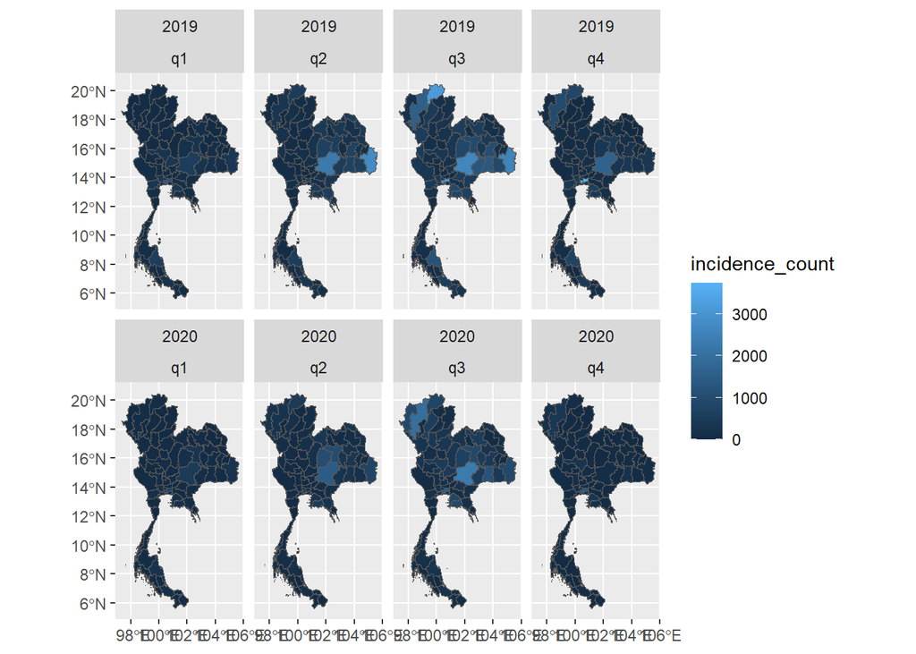

```r
ggplot(tha_map_merge_sf) + geom_sf(aes(fill=incidence_count)) + facet_wrap(vars(year,num_quarter),dir="h",ncol=4)
```

and here is another customization.

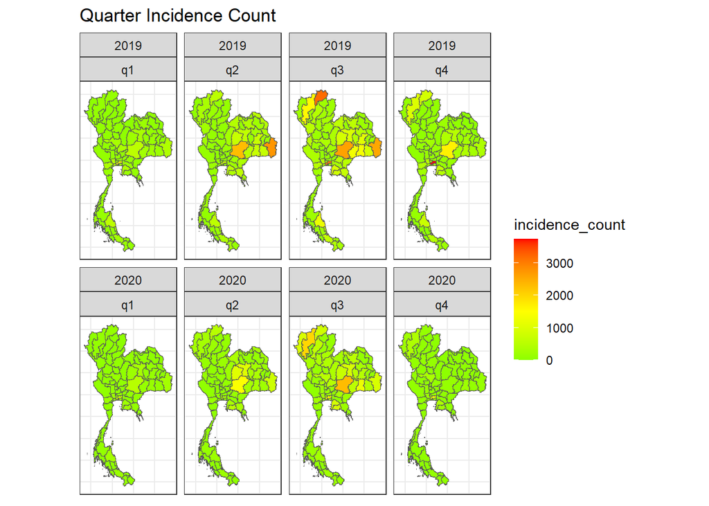

```r
ggplot(tha_map_merge_sf) + geom_sf(aes(fill=incidence_count)) + facet_wrap(vars(year,num_quarter),dir="h",ncol=4)+ggtitle("Quarter Incidence Count")+theme_bw()+theme(axis.text.x=element_blank(),axis.text.y=element_blank(),axis.ticks=element_blank())+scale_fill_gradient2(low='green',mid='yellow',high='red',midpoint=1500)
```

Moreover, above visualization could be exported as image file.

```r
ggsave("output/result.png")
```

# Some references

- https://readr.tidyverse.org/
- https://tidyr.tidyverse.org/
- https://cran.r-project.org/web/packages/rgdal/index.html
- https://ggplot2.tidyverse.org/